# Tutorial 2 keypoints

2023-03-04

> [*Back to content page*](https://flatter11.github.io/r.studio/)

# Q1 How to perform exploratory analysis

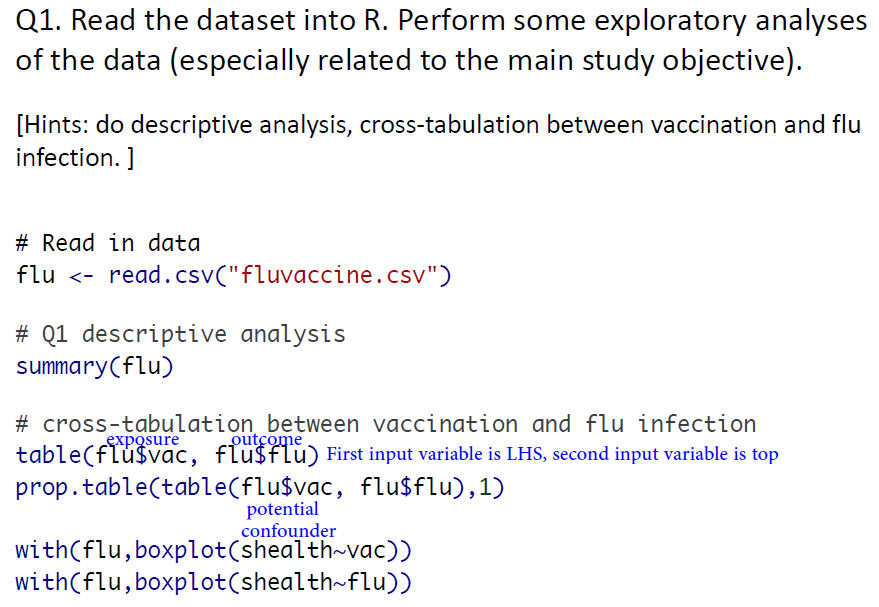

# Q2 Logistic regressison with glm

- Need to exp the beta!!!!!!!

# Q3,4,5 Confounders

- Use both 3 methods (Q3,5)
- Stratified analysis with for loop (Q4)
  - Note: Stratify(cut group) according to distribution of variable(summary)

# Q6,7 Effect modification

- Add interaction term
- Effect and 95%CI for each subgroup
  - Example
    - Effect for nonsmoker: `exp(model$coef["vac"])`
    - Effect for smoker: `exp(model$coef["vac"] + model$coef["vac:smoking])`
    - 95% for nonsmoker: `exp(confint.default(model)["vac",])`
    - 95% for smoker:
      - Find SE for smoker (pooled) = sqrt(a.var + b.var + 2*ab.cov) where a=vac, b=vac:smoking **see figure
        - by `vcov(model)`(variance-covariance of fitted model)
        - `sqrt(vcov(model)[2,2], vcov(model)[5,5], 2*vcov(model)[2,5])`
      - Hence 95% CI = effect ± 1.96*se `exp(lr.fvs.s$coef["vac"]+lr.fvs.s$coef["vac:smoking"] +` `c(-1,1)*qnorm(0.975)*se.vac.smoker)`

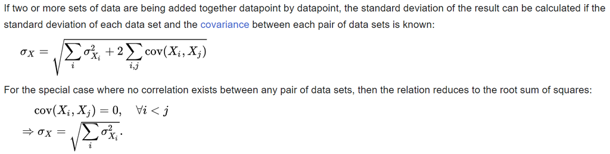

# Q8 Collinearity checking and solution

- Use `vif`
- Solve by centering
  - `flu$ct.age <- scale(flu$age, scale=F)`
  - `lr.fvs.act <- glm(flu~vac+shealth+vac*ct.age, data=flu, family=binomial)`
  - `vif(lr.fvs.act)` #collinearity problem solved!

# Q9 Mediation analysis

- Baron and Kenny criteria
  - Also include confounder, effect modification etc
- Don’t use sobel test coz binomial outcome!

# Q10 Model selection

- `step.model <- stepAIC(lr.fv, scope = list(upper = ~vac+shealth+bmi+vac*age+vac*smoking, lower = ~vac))` #specify the scope from upper=full model include all variables to lower=only exposure
  - FYI: lr.fv is glm(flu~vac, data=flu, family=binomial)

# Q11 Residual plot

- Difficult to interpret for logistic regression

# Q12 ROC (FYI)

# Q13 Summarize results

`round(exp(cbind(final.model$coef,confint.default(final.model))),2)` #round and combine adjusted odds ratio and 95%CI